# 205.1. PSF for deep coadd images

For the Rubin Science Platform at data.lsst.cloud.  
Data Release: [Data Preview 2](https://dp2.lsst.io/)  
Container Size: Large  
LSST Science Pipelines version: r30.0.11  
Last verified to run: 2026-08-18  
Repository: github.com/lsst/tutorial-notebooks  
DOI: 10.11578/rubin/dc.20250909.20

**Learning objective:** To understand the format and metadata of the Point Spread Function (PSF) in a coadded image, and how to access and characterize it in the DP2 `deep_coadd` data model.

**LSST data products:** `object`, `deep_coadd`

**Packages:** `lsst.daf.butler`, `lsst.afw.display`, `lsst.geom`, `astropy`, `numpy`, `matplotlib`, `scipy`, `galsim`.

**Credit:** Originally developed by the Rubin Community Science team. Please consider acknowledging them if this notebook is used for the preparation of journal articles, software releases, or other notebooks.

**Get Support:** Everyone is encouraged to ask questions or raise issues in the [Support Category](https://community.lsst.org/c/support) of the Rubin Community Forum. Rubin staff will respond to all questions posted there.

## 1. Introduction

This notebook demonstrates how to visualize the PSF model of a `deep_coadd` at a particular location, and how to explore the PSF model methods to calculate and visualize its properties. The final section shows an example of PSF model residual visualization.

In DP2, a `deep_coadd` is stored in the new `lsst.images` data model as a `CellCoadd` object. Its PSF is accessed through the `deep_coadd.psf` attribute, and its astrometric mapping through `deep_coadd.sky_projection` (see the DP2 tutorial on `deep_coadd` images and astrometric calibration). The PSF modeling was performed with the ["PSF in the Full Field of View"](https://ui.adsabs.harvard.edu/abs/2021ascl.soft02024J/abstract) (PIFF) software; the coadd PSF is a position-dependent weighted sum of the contributing single-visit PSF models.

The new PSF object provides `compute_kernel_image` and `compute_stellar_image` methods.

**Related tutorials:** See the DP2 tutorials on `deep_coadd` images, on the PSF in `visit_image`s, and on cosmological applications of PSF analysis.

### 1.1. Import packages

Import `numpy`, a fundamental package for scientific computing with arrays in Python (numpy.org), and `matplotlib`, a comprehensive library for data visualization ([matplotlib.org](https://matplotlib.org/); [matplotlib gallery](https://matplotlib.org/stable/gallery/index.html)).

From `scipy`, import tools for numerical optimization and statistics, including curve fitting and computation of distribution skewness ([scipy.org](https://scipy.org/)).

From `astropy`, import celestial coordinate and unit handling ([astropy.org](https://www.astropy.org/)).

Import `galsim`, the modular galaxy image simulation toolkit, for its HSM adaptive-moments interface (github.com/GalSim-developers/GalSim).

From the LSST Science Pipelines, import modules for display utilities, geometry handling, and the Butler data access system ([pipelines.lsst.io](https://pipelines.lsst.io/)).

```python
import matplotlib.pyplot as plt
import numpy as np
from scipy.optimize import curve_fit
from scipy.stats import skew
import galsim
from astropy.coordinates import SkyCoord
import astropy.units as u
import lsst.afw.display as afwDisplay
from lsst.images import Box
import lsst.geom
from lsst.daf.butler import Butler
```

### 1.2. Define parameters and functions

**Constant**: `SIGMA_TO_FWHM`

The conversion factor between the standard deviation `sigma` of a Gaussian function and the full-width at half-maximum (FWHM): $2\sqrt{2\ln(2)}$.

```python
SIGMA_TO_FWHM = 2.0*np.sqrt(2.0*np.log(2.0))
```

**Function**: `gauss`

A one-dimensional Gaussian profile.

```python
def gauss(x, a, x0, sigma):
    """Evaluate a 1D Gaussian function.

    Parameters
    ----------
    x : `array_like`
        Input values where the Gaussian is evaluated.
    a : `float`
        Amplitude of the Gaussian peak.
    x0 : `float`
        Mean (center) of the Gaussian.
    sigma : `float`
        Standard deviation (width) of the Gaussian.

    Returns
    -------
    y : `array_like`
        Values of the Gaussian evaluated at `x`.
    """
    return a * np.exp(-(x - x0)**2 / (2 * sigma**2))
```

Set `afwDisplay` to use `firefly` for image display.

```python
afwDisplay.setDefaultBackend('firefly')
afw_display = afwDisplay.Display(frame=1)
```

Instantiate the Butler with the DP2 repository and collection.

```python
butler = Butler("dp2", collections="dp2")
```

## 2. Retrieve the coadd and visualize the PSF model

Use a location near the center of the Extended Chandra Deep Field South (ECDFS), in degrees, and the *r* band.

```python
ra_cen, dec_cen = 53.076, -28.110
my_band = 'r'
```

Query the Butler for a `deep_coadd` that overlaps this location, and retrieve it. The returned object is a `CellCoadd`.

```python
query = f"band.name=:band AND patch.region OVERLAPS POINT(:ra, :dec)"
bind_params = {'band':my_band, 'ra':ra_cen, 'dec':dec_cen}

dataset_refs = butler.query_datasets("deep_coadd", where=query,
                                     bind=bind_params)
deep_coadd = butler.get(dataset_refs[0])
deep_coadd
```

```
CellCoadd
├── skymap: lsst_cells_v2
├── tract: 5063
├── patch: id=15, index=(y=1, x=5), inner_bbox=[y=3000:6000, x=15000:18000], cells=([y=2850:6150,
│   x=14850:18150], cell_shape=(y=150, x=150))
├── band: r
├── bbox: [y=2850:6150, x=14850:18150]
├── mask_fractions: rejected
├── noise_realizations: 1 image (dtype float32)
├── aperture_corrections: 64 fields
├── image: (dtype float32)
├── mask (Mask)
│   └── schema (MaskSchema)
│       ├── dtype: uint8
│       └── Mask planes
│           ┏━━━━━┳━━━━━━━┳━━━━━━┳━━━━━━━━━━━━━━━━┳━━━━━━━━━━━━━━━━━━━━━━━━━━━━━━━━━━━┳━━━━━━━━━━━━┓
│           ┃ Bit ┃ Index ┃ Mask ┃ Name           ┃ Description                       ┃ Set pixels ┃
│           ┡━━━━━╇━━━━━━━╇━━━━━━╇━━━━━━━━━━━━━━━━╇━━━━━━━━━━━━━━━━━━━━━━━━━━━━━━━━━━━╇━━━━━━━━━━━━┩
│           │ 0   │ 0     │ 0x1  │ NO_DATA        │ No data was available for this    │ 25321      │
│           │     │       │      │                │ pixel.                            │            │
│           │ 1   │ 0     │ 0x2  │ INTERPOLATED   │ Pixel value is the result of      │ 32543      │
│           │     │       │      │                │ interpolating nearby good pixels. │            │
│           │ 2   │ 0     │ 0x4  │ COSMIC_RAY     │ A cosmic ray affected this pixel  │ 7222       │
│           │     │       │      │                │ on at least one input image (and  │            │
│           │     │       │      │                │ was interpolated).                │            │
│           │ 3   │ 0     │ 0x8  │ SATURATED      │ More than 10% of the potential    │ 55499      │
│           │     │       │      │                │ input visits had a saturated      │            │
│           │     │       │      │                │ pixel at this location            │            │
│           │     │       │      │                │ ('potential' because saturated    │            │
│           │     │       │      │                │ pixel values are not actually     │            │
│           │     │       │      │                │ propagated to the coadd).         │            │
│           │     │       │      │                │ SATURATED always implies          │            │
│           │     │       │      │                │ REJECTED, and is often a reason   │            │
│           │     │       │      │                │ for NO_DATA.                      │            │
│           │ 4   │ 0     │ 0x10 │ DETECTION_EDGE │ Pixel was too close to the edge   │ 92204      │
│           │     │       │      │                │ of the patch to be considered for │            │
│           │     │       │      │                │ detection, due to the finite size │            │
│           │     │       │      │                │ of the detection kernel.          │            │
│           │ 5   │ 0     │ 0x20 │ CLIPPED        │ Region was identified as a        │ 817        │
│           │     │       │      │                │ probable artifact when comparing  │            │
```

[output cut: 26 more lines]

```
│       │ 18149.5 │ 6149.5 │ 03h31m33.4s │ -28d00m44s │ 52.889312 │ -28.012146 │
│       │ 18149.5 │ 2849.5 │ 03h31m33.4s │ -28d11m44s │ 52.888979 │ -28.195459 │
│       └─────────┴────────┴─────────────┴────────────┴───────────┴────────────┘
├── psf (CellPointSpreadFunction)
│   ├── bounds: [y=2850:6150, x=14850:18150] in grid ([y=2850:6150, x=14850:18150],
│   │   cell_shape=(y=150, x=150))
│   └── kernel_bbox: [y=-17:18, x=-17:18]
├── provenance (CoaddProvenance)
│   ├── instrument: LSSTCam
│   ├── physical_filter: r_57
│   ├── input images: 98 from 31 visits
│   ├── day_obs: 20250728 - 20260105
│   ├── cells: 484 of 484 with contributions
│   └── per cell: 13 - 28 input images (median 22)
└── backgrounds: pretty, object (subtracted)
```

Get the PSF model and the sky projection (WCS) from the coadd.

```python
psf = deep_coadd.psf
wcs = deep_coadd.sky_projection
```

> **Note:** Here `psf` and `wcs` are taken from the `deep_coadd` object loaded above. When the full image is not needed, each can instead be read directly from the Butler as a component—for example `butler.get("deep_coadd.psf", ...)` and `butler.get("deep_coadd.sky_projection", ...)`—without loading the whole coadd.

Convert the central sky coordinate to pixel coordinates (in the tract system used by the coadd).

```python
center = SkyCoord(ra=ra_cen*u.deg, dec=dec_cen*u.deg, frame='icrs')
xy = wcs.sky_to_pixel(center)
x_pix, y_pix = xy.x, xy.y
print(f"pixel position: ({x_pix: .1f}, {y_pix: .1f})")
```

```
pixel position: ( 15182.5,  4390.5)
```

Use the `compute_kernel_image` method to evaluate the PSF at the chosen point. This returns an `lsst.images.Image` centered on the origin (0, 0), suitable for convolution.

```python
psf_kernel_image = psf.compute_kernel_image(x=x_pix, y=y_pix)
afw_display = afwDisplay.Display(frame=1)
afw_display.scale('asinh', 'zscale')
afw_display.mtv(psf_kernel_image)
```

> **Figure 1:** PSF model from the `compute_kernel_image` method, centered on the origin.

Use the `compute_stellar_image` method. This evaluates the PSF centered on the given coordinates, just like the postage stamp of a star would appear, which is convenient for comparison with observed stars.

```python
psf_stellar_image = psf.compute_stellar_image(x=x_pix, y=y_pix)

afw_display = afwDisplay.Display(frame=2)
afw_display.scale('asinh', 'zscale')
afw_display.mtv(psf_stellar_image)
```

> **Figure 2:** PSF model from the `compute_stellar_image` method, centered on the star position.

The `compute_stellar_bbox` method returns the bounding box of the image that `compute_stellar_image` would produce at a given position, without computing the image itself. This is useful to know the size and location of the stamp in advance.

```python
stellar_bbox = psf.compute_stellar_bbox(x=x_pix, y=y_pix)
stellar_bbox
```

```
Box(y=Interval(start=4374, stop=4409), x=Interval(start=15166, stop=15201))
```

## 3. PSF size and shape

The `CellCoadd` PSF (`deep_coadd.psf`, a `CellPointSpreadFunction`) does not provide the shape, second-moment, aperture-flux, or peak methods that the DP1 `afw` PSF had. This tutorial measures the PSF size and shape with the GalSim HSM adaptive moments (Section 3.2); the postage-stamp dimensions are read directly from the PSF image array (Section 3.1).

### 3.1. Postage stamp dimensions

Get the PSF postage stamp dimensions, in pixels, from the kernel image array.

```python
psf_image_array = psf_kernel_image.array
ylen, xlen = psf_image_array.shape
print(f"PSF postage stamp dimensions: {xlen} x {ylen} pix")
```

```
PSF postage stamp dimensions: 35 x 35 pix
```

### 3.2. PSF size and shape with GalSim HSM

An independent way to characterize the PSF size and shape is with adaptive moments, using the HSM algorithm ([Hirata & Seljak 2003](https://ui.adsabs.harvard.edu/abs/2003MNRAS.343..459H/abstract); [Mandelbaum et al. 2005](https://ui.adsabs.harvard.edu/abs/2005MNRAS.361.1287M/abstract)) as implemented in GalSim. `galsim.hsm.FindAdaptiveMom` fits an elliptical Gaussian to the image and returns the adaptive-moments size `moments_sigma` (the determinant radius $|\det M|^{1/4}$, in pixels) and the `observed_shape` (a `Shear` with ellipticity components `e1` and `e2`). The HSM algorithm is the same algorithm that is used to measure PSF moments that are tabulated in various DP2 catalogs.

Wrap the PSF kernel image array in a `galsim.Image` with a pixel scale of 1 (so the size is measured in pixels), and run the adaptive-moments measurement.

```python
gs_image = galsim.Image(np.ascontiguousarray(psf_kernel_image.array), scale=1.0)
hsm_result = galsim.hsm.FindAdaptiveMom(gs_image, guess_sig=3.0)
```

Report the HSM size, full-width at half maximum, and ellipticity.

```python
hsm_sigma = hsm_result.moments_sigma
hsm_fwhm = hsm_sigma * SIGMA_TO_FWHM
shape = hsm_result.observed_shape
print(f"HSM size (moments_sigma): {hsm_sigma: .3f} pix")
print(f"HSM FWHM: {hsm_fwhm: .3f} pix")
print(f"HSM ellipticity: e1 = {shape.e1: .4f}, e2 = {shape.e2: .4f}, |e| = {shape.e: .4f}")
```

```
HSM size (moments_sigma):  2.161 pix
HSM FWHM:  5.090 pix
HSM ellipticity: e1 =  0.0135, e2 = -0.0051, |e| =  0.0145
```

## 4. PSF radial profile

Create a coordinate grid and calculate the distance from each pixel to the center. Using the `meshgrid` method associated with the psf bbox retrieves coordinates with (0, 0) at the center of the kernel image.

```python
xx, yy = psf_kernel_image.bbox.meshgrid()
coords = np.stack((xx, yy), axis=-1)
distances = np.linalg.norm(coords, axis=-1)
```

Apply a radial mask.

```python
mask = distances <= xlen / 2
values = psf_image_array[mask]
dists = distances[mask]
```

Set initial parameters and bounds for a Gaussian fit of the radial profile.

```python
p0 = [np.max(values), 0, 10]
bounds = ((0, 0, 0), (np.inf, np.inf, np.inf))
```

Fit a Gaussian profile.

```python
try:
    pars, _ = curve_fit(gauss, dists, values, p0=p0, bounds=bounds)
    pars[0] = np.abs(pars[0])
    pars[2] = np.abs(pars[2])
except RuntimeError:
    pars = None
```

Plot the radial profile.

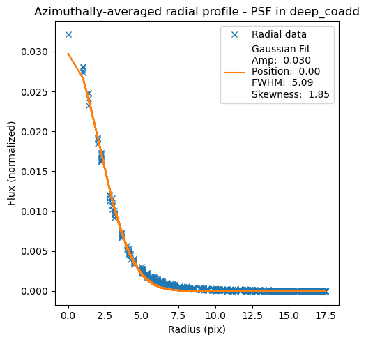

```python
fig, ax = plt.subplots(figsize=(6, 5))
ax.plot(dists, values, 'x', label='Radial data')

if pars is not None:
    fitAmp, fitMean, fitSigma = pars
    fitFwhm = fitSigma * SIGMA_TO_FWHM
    x_fit = np.linspace(-np.max(dists), np.max(dists), 200)
    skewness_val = skew(gauss(x_fit, *pars))
    ax.plot(dists, gauss(dists, *pars), label=(
        f"Gaussian Fit\n"
        f"Amp: {fitAmp: .3f}\n"
        f"Position: {fitMean: .2f}\n"
        f"FWHM: {fitFwhm: .2f}\n"
        f"Skewness: {skewness_val: .2f}"))

ax.set_xlabel("Radius (pix)")
ax.set_ylabel("Flux (normalized)")
ax.set_title("Azimuthally-averaged radial profile - PSF in deep_coadd")
ax.set_aspect(1.0 / ax.get_data_ratio(), adjustable='box')
ax.legend()
plt.tight_layout()
plt.show()
```

> **Figure 3:** Azimuthally-averaged PSF radial profile, fitted with a Gaussian function.

## 5. PSF curve of growth (encircled energy)

Sort the distances calculated above.

```python
sorted_indices = np.argsort(dists)
dists_sorted = dists[sorted_indices]
values_sorted = values[sorted_indices]
```

Compute the normalized cumulative flux.

```python
cum_fluxes = np.cumsum(values_sorted)
cum_fluxes_norm = cum_fluxes / np.max(cum_fluxes)
```

Plot the curve of growth.

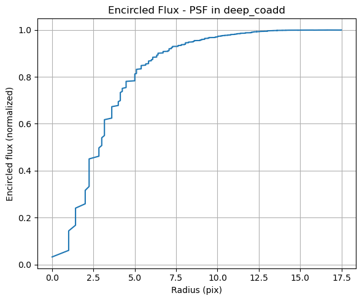

```python
fig, ax = plt.subplots(figsize=(6, 5))
ax.plot(dists_sorted, cum_fluxes_norm, markersize=10)
ax.set_ylabel('Encircled flux (normalized)')
ax.set_xlabel('Radius (pix)')
ax.set_title("Encircled Flux - PSF in deep_coadd")
ax.grid(True)
plt.tight_layout()
plt.show()
```

> **Figure 4:** PSF curve of growth.

## 6. Make a 2D PSF contour plot

Define intensity percentiles for the contour levels.

```python
vmin = np.percentile(psf_image_array, 0.1)
vmax = np.percentile(psf_image_array, 99.9)
nContours = 10
lvls = np.linspace(vmin, vmax, nContours)
```

Define a coordinate grid centered around (0, 0).

```python
xg, yg = np.meshgrid(np.linspace(-xlen / 2, xlen / 2, xlen),
                     np.linspace(-ylen / 2, ylen / 2, ylen))
```

Plot the contours.

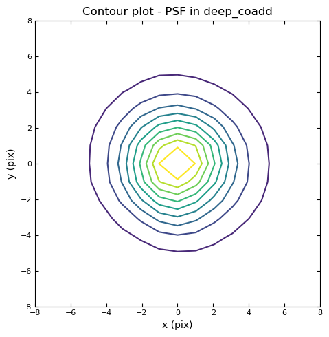

```python
fig, ax = plt.subplots(figsize=(6, 5))
ax.contour(xg, yg, psf_image_array, levels=lvls)
ax.tick_params(which="both", direction="in", top=True, right=True, labelsize=8)
ax.set_aspect("equal")
ax.set_xlabel('x (pix)')
ax.set_ylabel('y (pix)')
ax.set_title("Contour plot - PSF in deep_coadd")
ax.set_xlim([-8, 8])
ax.set_ylim([-8, 8])
plt.tight_layout()
plt.show()
```

> **Figure 5:** PSF contour plot.

## 7. PSF model residuals

Find stars used for PSF modeling in the `object` catalog by selecting the `{band}_calib_psf_used` flag, retrieved from the Butler for the coadd's tract. For one star, display the residuals between the PSF model at the star location and the observed star.

Get the tract and patch of the `deep_coadd`.

```python
data_id = dataset_refs[0].dataId
my_tract = data_id['tract']
my_patch = data_id['patch']
print('tract:', my_tract, '| patch:', my_patch)
```

```
tract: 5063 | patch: 15
```

Retrieve the `object` catalog for the tract, selecting only the columns needed. The `object` catalog contains all objects in the tract, so restrict to the coadd's patch.

```python
columns = ["patch", "refExtendedness",
           f"{my_band}_calib_psf_used",
           f"{my_band}_pixelFlags_inexact_psfCenter",
           f"{my_band}_psfFlux", f"{my_band}_psfFluxErr",
           "coord_ra", "coord_dec"]
objects = butler.get("object", tract=my_tract, skymap="lsst_cells_v2",
                     parameters={"columns": columns})
```

> **Note:** Here `refExtendedness` = 0 selects point-like sources, and is used for illustration. LSST DP2 provides several derived quantities that can be used for star–galaxy separation, described in the [DP2 schema](https://sdm-schemas.lsst.io/lsstcam.html):
> - `{band}_extendedness` (binary): classifies an object as a point source (0) if its PSF flux exceeds 0.985 times its cModel flux, and as extended (1) otherwise.
> - `refExtendedness` (binary): the `{band}_extendedness` measured in the object's reference band (chosen per object by detection significance, in the priority order i, r, z, y, g, u).
> - `{band}_sizeExtendedness` (binary): a likelihood-based comparison of the object's HSM moments and PSF size (measured on the g band by default).
> - `{band}_model_extendedness` (floating point): a Sérsic-plus-PSF flux and size estimate of whether an object is point-like or extended.
> - `griz_model_extendedness` (floating point): a multi-band (griz) Sérsic-model flux and size estimate.

> The most suitable classifier depends on the science case.

Select point-like sources used in PSF modeling, in this patch, with a high signal-to-noise ratio.

```python
snr = (np.asarray(objects[f"{my_band}_psfFlux"])
       / np.asarray(objects[f"{my_band}_psfFluxErr"]))
mask = ((np.asarray(objects["patch"]) == my_patch)
        & (np.asarray(objects["refExtendedness"]) == 0.0)
        & np.asarray(objects[f"{my_band}_calib_psf_used"])
        & ~np.asarray(objects[f"{my_band}_pixelFlags_inexact_psfCenter"])
        & (snr > 50))
star_ra = np.asarray(objects["coord_ra"])[mask]
star_dec = np.asarray(objects["coord_dec"])[mask]
print(len(star_ra))
```

```
52
```

Get the bounding box (`bbox`) for the deep coadd image, and find the first PSF star that falls within it.

```python
bbox = deep_coadd.bbox

position_star = None
for ra_star, dec_star in zip(star_ra, star_dec):
    coord = SkyCoord(ra=ra_star*u.deg, dec=dec_star*u.deg, frame='icrs')
    pixel_point = wcs.sky_to_pixel(coord)
    if bbox.contains(x=pixel_point.x, y=pixel_point.y):
        position_star = pixel_point
        break

position_star
```

```
XY(x=16130.208090528844, y=3291.1001875072616)
```

Evaluate the PSF model at the star location with `compute_stellar_image`, and normalize it.

```python
psf_model = psf.compute_stellar_image(x=position_star.x,
                                      y=position_star.y)
psf_array = psf_model.array
psf_array = psf_array / np.sum(psf_array)
stamp_ny, stamp_nx = psf_array.shape
```

Use the dimensions of the PSF model image as the cutout size, then make a cutout around the star from the deep coadd and normalize its flux values.

```python
psf_bbox = psf_model.bbox
cutout_bbox = Box.factory[psf_bbox.y.start:psf_bbox.y.stop, psf_bbox.x.start:psf_bbox.x.stop]
```

```python
star_cutout = deep_coadd[cutout_bbox].copy()
```

```python
star_image_array = star_cutout.image.array
star_image_array /= star_image_array.sum()
```

Plot the observed star, the PSF model at that location, and the residuals.

```python
max_star = np.max(np.abs(star_image_array))
PSF_model_name = "Piff"
print(max_star)
```

```
0.028992428
```

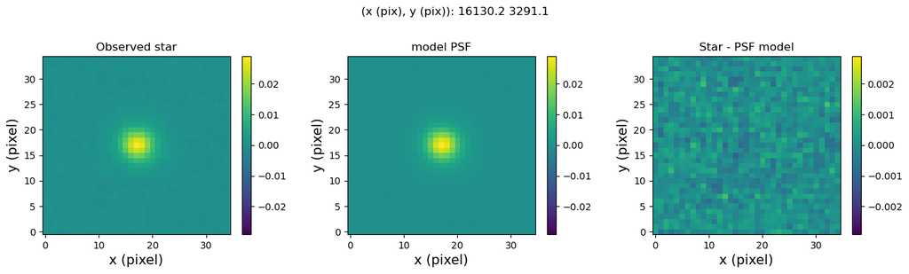

```python
fig, axes = plt.subplots(1, 3, figsize=(14, 4))
fig.subplots_adjust(wspace=0.3, left=0.07, right=0.95, bottom=0.15, top=0.8)
fig.suptitle(f"(x (pix), y (pix)): {np.round(position_star.x, 1)} {np.round(position_star.y, 1)}", fontsize=12)

images = [
    (star_image_array, 'Observed star', max_star),
    (psf_array, 'model PSF', max_star),
    (star_image_array - psf_array,
     'Star - PSF model', max_star/10)
]

for ax, (img, title, v) in zip(axes, images):
    im = ax.imshow(img, vmin=-v, vmax=v, cmap='viridis',
                   origin='lower', aspect='auto')
    fig.colorbar(im, ax=ax)
    ax.set_xlabel('x (pixel)', fontsize=14)
    ax.set_ylabel('y (pixel)', fontsize=14)
    ax.set_title(title, fontsize=12)
```

> **Figure 6:** Measured star used for PSF modeling (left), PSF model (center), and residuals (right).